# Reproducible Research: Peer Assessment 1

Aga Bey

4/16/2021

### 1)

Loading and preprocessing the data

```r
library(ggplot2, warn.conflicts = FALSE)
library(dplyr, warn.conflicts = FALSE)
library(lubridate, warn.conflicts = FALSE)

# Read in data
activities <- read.csv(unzip("activity.zip"))      # 17568 X 3 dataframe

# Lubridate as_datetime function changes 2nd column to datetime:
activities$date <- as_datetime(activities$date)
```

### 2)

What is the mean total number of steps taken per day?

Calculate the total number of steps taken per day:

```r
grouped_activities <- activities %>%
  na.omit(activities) %>%    # Now a 15264 X 3 dataframe
  group_by(date) %>%
  summarize(sum_steps=sum(steps), .groups = 'drop')
```

Make a histogram of the total number of steps per day.

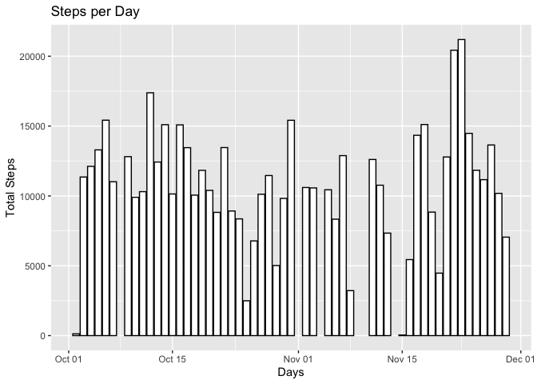

```r
 ggplot(grouped_activities,aes(x=date, y=sum_steps)) +
 geom_bar(stat="identity", fill = "white", colour = "black") +
 ggtitle("Steps per Day ") +
 labs(x="Days", y = "Total Steps")
```

Calculate the mean and median of the total number of steps per day

```r
mean(grouped_activities$sum_steps)
```

```
## [1] 10766.19
```

```r
median(grouped_activities$sum_steps)
```

```
## [1] 10765
```

### 3)

What is the average daily activity pattern?

Make a time series plot of the 5-minute interval (x-axis) and the  
average number of steps taken, averaged across all days (y-axis).

```r
stepsInterval <- activities %>%
  na.omit(activities) %>%    # Now a 15264 X 3 dataframe
  group_by(interval) %>%
  summarize(mean_steps=mean(steps), .groups = 'drop')
```

**stepsInterval** is a dataframe of 288 five-minute intervals and their means.  
To make a time-series plot we need to convert these intervals to time periods.

```r
# First create column containing total seconds elapsed:
seconds_vector <- (stepsInterval$interval%/%100) * 60 * 60 + stepsInterval$interval%%100 *60

# Now use Lubridate function to convert seconds to a period of time:
stepsInterval$time <-hms::as_hms(seconds_vector)
```

Now we can use ggplot2 to make a time series plot:

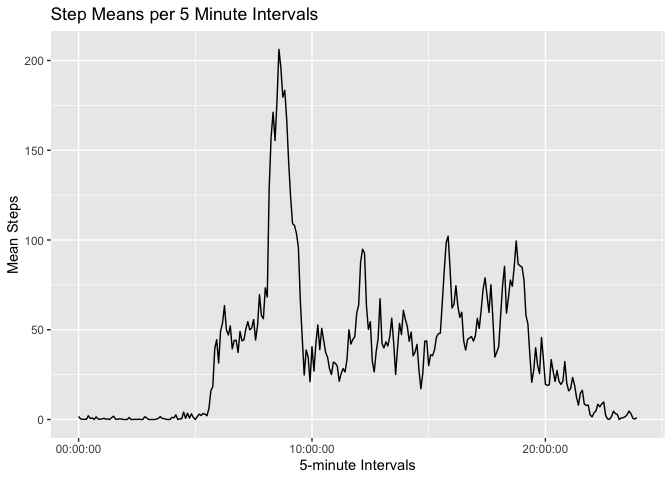

```r
ggplot(stepsInterval, aes(x=time, y=mean_steps)) +
  geom_line() +
  ggtitle("Step Means per 5 Minute Intervals") +
  labs(x="5-minute Intervals", y = "Mean Steps")
```

Which 5-minute interval contains the maximum number of steps?

```r
stepsInterval$time[which.max(stepsInterval$mean_steps)]
```

```
## 08:35:00
```

Or presented in the original data format…  
The 5-minute interval:

```r
stepsInterval$interval[which.max(stepsInterval$mean_steps)]
```

```
## [1] 835
```